```python
from IPython.display import display, Markdown

def print_header(text, level=2):
    display(Markdown(f"{'#'*level} {text}"))
```

# Using Past Weather Data to Predict Future Weather

## Step 1: Import Neccessary Libraries

```python
%pip install pandas numpy matplotlib seaborn scikit-learn
```

**Functions of Libraries Installed**

pandas - handle datasets  
numpy - numerical data  
matplotlib and seaborn - data visualization  
scikit-learn - build machine learning model

## Step 2: Import Weather Data

The weather_prediction_dataset.csv from Zenodo describes various meteorological variables for daily records across 18 European cities from 2000 to 2010. This dataset is used to predict future weather conditions.

```python
import pandas as pd

# URL of Dataset on Zenodo, across locations in Europe
url = 'https://zenodo.org/records/4770937/files/weather_prediction_dataset.csv'

# Load Dataset
df = pd.read_csv(url)

# Display basic information about dataset
df.info()
```

```
<class 'pandas.core.frame.DataFrame'>
RangeIndex: 3654 entries, 0 to 3653
Columns: 165 entries, DATE to TOURS_temp_max
dtypes: float64(150), int64(15)
memory usage: 4.6 MB
```

```python
# Display Preview and Summary of Dataset

print_header("Dataset Preview")
display(df.head().style.set_caption("First 5 Rows").background_gradient(cmap='Blues'))

print_header("Dataset Summary")
display(df.describe().T.style.bar(color='#5fba7d'))
```

Dataset Preview

First 5 Rows

|  | DATE | MONTH | BASEL_cloud_cover | BASEL_humidity | BASEL_pressure | BASEL_global_radiation | BASEL_precipitation | BASEL_sunshine | BASEL_temp_mean | BASEL_temp_min | BASEL_temp_max | BUDAPEST_cloud_cover | BUDAPEST_humidity | BUDAPEST_pressure | BUDAPEST_global_radiation | BUDAPEST_precipitation | BUDAPEST_sunshine | BUDAPEST_temp_mean | BUDAPEST_temp_max | DE_BILT_cloud_cover | DE_BILT_wind_speed | DE_BILT_wind_gust | DE_BILT_humidity | DE_BILT_pressure | DE_BILT_global_radiation | DE_BILT_precipitation | DE_BILT_sunshine | DE_BILT_temp_mean | DE_BILT_temp_min | … |
| --- | --- | --- | --- | --- | --- | --- | --- | --- | --- | --- | --- | --- | --- | --- | --- | --- | --- | --- | --- | --- | --- | --- | --- | --- | --- | --- | --- | --- | --- | --- |
| 0 | 20000101 | 1 | 8 | 0.890000 | 1.028600 | 0.200000 | 0.030000 | 0.000000 | 2.900000 | 1.600000 | 3.900000 | 3 | 0.920000 | 1.026800 | 0.520000 | 0.000000 | 3.700000 | -4.900000 | -0.700000 | 7 | 2.500000 | 8.000000 | 0.970000 | 1.024000 | 0.110000 | 0.100000 | 0.000000 | 6.100000 | 3.500000 | … |
| 1 | 20000102 | 1 | 8 | 0.870000 | 1.031800 | 0.250000 | 0.000000 | 0.000000 | 3.600000 | 2.700000 | 4.800000 | 8 | 0.940000 | 1.029700 | 0.140000 | 0.000000 | 0.400000 | -3.600000 | -1.900000 | 8 | 3.700000 | 9.000000 | 0.970000 | 1.026700 | 0.110000 | 0.000000 | 0.000000 | 7.300000 | 5.400000 | … |
| 2 | 20000103 | 1 | 5 | 0.810000 | 1.031400 | 0.500000 | 0.000000 | 3.700000 | 2.200000 | 0.100000 | 4.800000 | 6 | 0.950000 | 1.029500 | 0.190000 | 0.000000 | 0.000000 | -0.800000 | 1.100000 | 8 | 6.100000 | 13.000000 | 0.940000 | 1.020300 | 0.110000 | 0.450000 | 0.000000 | 8.400000 | 6.400000 | … |
| 3 | 20000104 | 1 | 7 | 0.790000 | 1.026200 | 0.630000 | 0.350000 | 6.900000 | 3.900000 | 0.500000 | 7.500000 | 8 | 0.940000 | 1.025200 | 0.210000 | 0.000000 | 0.000000 | -1.000000 | 0.100000 | 7 | 3.800000 | 15.000000 | 0.940000 | 1.014200 | 0.110000 | 1.090000 | 0.000000 | 6.400000 | 4.300000 | … |
| 4 | 20000105 | 1 | 5 | 0.900000 | 1.024600 | 0.510000 | 0.070000 | 3.700000 | 6.000000 | 3.800000 | 8.600000 | 5 | 0.880000 | 1.023500 | 0.430000 | 0.000000 | 0.800000 | 0.200000 | 3.900000 | 3 | 4.000000 | 12.000000 | 0.900000 | 1.018300 | 0.480000 | 0.000000 | 6.500000 | 4.400000 | 1.400000 | … |

Dataset Summary

|  | count | mean | std | min | 25% | 50% | 75% | max |
| --- | --- | --- | --- | --- | --- | --- | --- | --- |
| DATE | 3654.000000 | 20045678.754242 | 28742.871733 | 20000101.000000 | 20020702.250000 | 20045666.000000 | 20070702.750000 | 20100101.000000 |
| MONTH | 3654.000000 | 6.520799 | 3.450083 | 1.000000 | 4.000000 | 7.000000 | 10.000000 | 12.000000 |
| BASEL_cloud_cover | 3654.000000 | 5.418446 | 2.325497 | 0.000000 | 4.000000 | 6.000000 | 7.000000 | 8.000000 |
| BASEL_humidity | 3654.000000 | 0.745107 | 0.107788 | 0.380000 | 0.670000 | 0.760000 | 0.830000 | 0.980000 |
| BASEL_pressure | 3654.000000 | 1.017876 | 0.007962 | 0.985600 | 1.013300 | 1.017700 | 1.022700 | 1.040800 |
| BASEL_global_radiation | 3654.000000 | 1.330380 | 0.935348 | 0.050000 | 0.530000 | 1.110000 | 2.060000 | 3.550000 |
| BASEL_precipitation | 3654.000000 | 0.234849 | 0.536267 | 0.000000 | 0.000000 | 0.000000 | 0.210000 | 7.570000 |
| BASEL_sunshine | 3654.000000 | 4.661193 | 4.330112 | 0.000000 | 0.500000 | 3.600000 | 8.000000 | 15.300000 |
| BASEL_temp_mean | 3654.000000 | 11.022797 | 7.414754 | -9.300000 | 5.300000 | 11.400000 | 16.900000 | 29.000000 |
| BASEL_temp_min | 3654.000000 | 6.989135 | 6.653356 | -16.000000 | 2.000000 | 7.300000 | 12.400000 | 20.800000 |
| BASEL_temp_max | 3654.000000 | 15.536782 | 8.721323 | -5.700000 | 8.700000 | 15.800000 | 22.300000 | 38.600000 |
| BUDAPEST_cloud_cover | 3654.000000 | 4.890531 | 2.386442 | 0.000000 | 3.000000 | 5.000000 | 7.000000 | 8.000000 |
| BUDAPEST_humidity | 3654.000000 | 0.656505 | 0.149603 | 0.260000 | 0.540000 | 0.650000 | 0.770000 | 1.000000 |
| BUDAPEST_pressure | 3654.000000 | 1.016935 | 0.007795 | 0.989100 | 1.012100 | 1.016500 | 1.021475 | 1.043800 |
| BUDAPEST_global_radiation | 3654.000000 | 1.465487 | 0.977986 | 0.040000 | 0.580000 | 1.340000 | 2.310000 | 3.490000 |
| BUDAPEST_precipitation | 3654.000000 | 0.136442 | 0.408932 | 0.000000 | 0.000000 | 0.000000 | 0.030000 | 6.960000 |
| BUDAPEST_sunshine | 3654.000000 | 5.753229 | 4.475439 | 0.000000 | 1.100000 | 5.900000 | 9.600000 | 14.900000 |
| BUDAPEST_temp_mean | 3654.000000 | 12.174849 | 8.744451 | -9.800000 | 5.100000 | 12.800000 | 19.300000 | 33.100000 |
| BUDAPEST_temp_max | 3654.000000 | 16.629091 | 9.981538 | -6.600000 | 8.400000 | 17.400000 | 25.000000 | 40.100000 |
| DE_BILT_cloud_cover | 3654.000000 | 5.303229 | 2.279416 | 0.000000 | 4.000000 | 6.000000 | 7.000000 | 8.000000 |
| DE_BILT_wind_speed | 3654.000000 | 3.395293 | 1.422020 | 0.700000 | 2.300000 | 3.200000 | 4.200000 | 10.300000 |
| DE_BILT_wind_gust | 3654.000000 | 9.986316 | 3.582408 | 2.000000 | 7.000000 | 10.000000 | 12.000000 | 28.000000 |
| DE_BILT_humidity | 3654.000000 | 0.817882 | 0.097465 | 0.370000 | 0.760000 | 0.830000 | 0.890000 | 1.000000 |
| DE_BILT_pressure | 3654.000000 | 1.015299 | 0.009861 | 0.973200 | 1.009400 | 1.015700 | 1.021700 | 1.044900 |
| DE_BILT_global_radiation | 3654.000000 | 1.190903 | 0.870267 | 0.110000 | 0.410000 | 1.020000 | 1.860000 | 3.410000 |
| DE_BILT_precipitation | 3654.000000 | 0.236888 | 0.459495 | 0.000000 | 0.000000 | 0.010000 | 0.290000 | 4.250000 |
| DE_BILT_sunshine | 3654.000000 | 4.744444 | 3.995637 | 0.000000 | 1.100000 | 4.100000 | 7.500000 | 15.500000 |
| DE_BILT_temp_mean | 3654.000000 | 10.703530 | 6.190770 | -7.900000 | 6.200000 | 11.000000 | 15.500000 | 26.900000 |
| DE_BILT_temp_min | 3654.000000 | 6.397099 | 5.639597 | -14.400000 | 2.300000 | 6.800000 | 10.800000 | 20.800000 |
| DE_BILT_temp_max | 3654.000000 | 14.798604 | 7.210740 | -4.700000 | 9.200000 | 14.900000 | 20.200000 | 35.700000 |

[output cut: 135 more lines]

**Term Definitions**

count = total of non missing values (null)  
mean = average  
std = standard deviation  
min = minimum value  
25% = 25% of data (lower quartile)  
50% = 50% of data (median)  
75% = 75% of data (upper quartile)  
max = maximum value

## Step 3: Check Missing Values

```python
print_header("Data Types & Missing Values")
display(pd.DataFrame({
    'Data Type': df.dtypes,
    'Missing Values': df.isna().sum(),
    '% Missing': (df.isna().mean()*100).round(2)
}))
```

Data Types & Missing Values

|  | Data Type | Missing Values | % Missing |
| --- | --- | --- | --- |
| DATE | int64 | 0 | 0.0 |
| MONTH | int64 | 0 | 0.0 |
| BASEL_cloud_cover | int64 | 0 | 0.0 |
| BASEL_humidity | float64 | 0 | 0.0 |
| BASEL_pressure | float64 | 0 | 0.0 |
| ... | ... | ... | ... |
| TOURS_global_radiation | float64 | 0 | 0.0 |
| TOURS_precipitation | float64 | 0 | 0.0 |
| TOURS_temp_mean | float64 | 0 | 0.0 |
| TOURS_temp_min | float64 | 0 | 0.0 |
| TOURS_temp_max | float64 | 0 | 0.0 |

165 rows × 3 columns

## Step 4: Data Preprocessing

```python
# 1. Handle Missing Values
df = df.dropna() # Drop rows with missing values
```

```python
# 2. Encode Categorical Data (One-Hot Encoding Method) - Turn categorical data into numerical data
df = pd.get_dummies(df, drop_first=True) # Drop first column
```

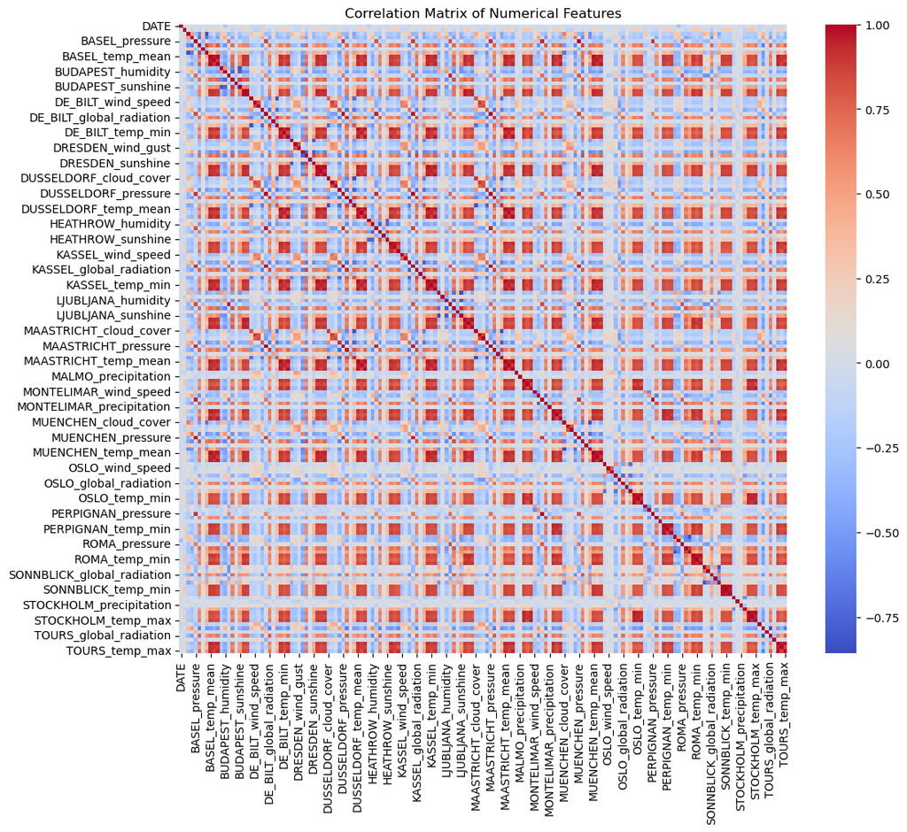

```python
# 3. Visualize Correlation Matrix
import seaborn as sns
import matplotlib.pyplot as plt

plt.figure(figsize=(12, 10))
sns.heatmap(df.corr(numeric_only=True), cmap='coolwarm', annot=False)
plt.title("Correlation Matrix of Numerical Features")
plt.show()
```

**Correlation Matrix**

A correlation matrix is a table showing correlation coefficients (r) between pairs of variables. Each value ranges from -1 to 1 and tells you how strongly and in what direction two variables are related.

**Correlation Value (r) Interpretation**

+1.0 > Perfect positive correlation  
+0.7 to +0.9 > Strong positive correlation  
+0.4 to +0.6 > Moderate positive correlation  
+0.1 to +0.3 > Weak positive correlation  
0 > No correlation  
-0.1 to -0.3 > Weak negative correlation  
-0.4 to -0.6 > Moderate negative correlation  
-0.7 to -0.9 > Strong negative correlation  
-1.0 > Perfect negative correlation

```python
# 4. Feature Selection
# Define Features and Target Variable

X1 = df.drop('BASEL_temp_mean', axis=1) #axis is column
y1 = df['BASEL_temp_mean']

X2 = df.drop('BASEL_humidity', axis=1)
y2 = df['BASEL_humidity']

X3 = df.drop('BASEL_pressure', axis=1)
y3 = df['BASEL_pressure']
```

## Step 5: Split the Data

```python
from sklearn.model_selection import train_test_split

# Split Data Temperature
X1_train, X1_test, y1_train, y1_test = train_test_split(X1, y1, test_size=0.2, random_state=42)

# Split Data Humidity
X2_train, X2_test, y2_train, y2_test = train_test_split(X2, y2, test_size=0.2, random_state=42)

# Split Data Pressure
X3_train, X3_test, y3_train, y3_test = train_test_split(X3, y3, test_size=0.2, random_state=42)
```

## Step 6: Build and Train the Model

```python
from sklearn.linear_model import LinearRegression

# Init Temperature Model
model_temp = LinearRegression()
# Train Temperature Model
model_temp.fit(X1_train, y1_train)

# Init Humidity Model
model_humidity = LinearRegression()
# Train Humidity Model
model_humidity.fit(X2_train, y2_train)

# Init Pressure Model
model_pressure = LinearRegression()
# Train Pressure Model
model_pressure.fit(X3_train, y3_train)
```

```
LinearRegression()
```

## Step 7: Evaluate the Model

```python
from sklearn.metrics import mean_squared_error, r2_score

# -----Temperature Predictions-----
y1_pred = model_temp.predict(X1_test)

# Calc Mean Squared Error
mse_1 = mean_squared_error(y1_test, y1_pred)

# Calc R-Squared Score
r2_1 = r2_score(y1_test, y1_pred)

# Print Results
print("Temperature Evaluation")
print(f"Mean Squared Error: {mse_1}")
print(f"R2 Score: {r2_1}")
print()

# -----Humidity Predictions-----
y2_pred = model_humidity.predict(X2_test)

# Calc Mean Squared Error
mse_2 = mean_squared_error(y2_test, y2_pred)

# Calc R-Squared Score
r2_2 = r2_score(y2_test, y2_pred)

# Print Results
print("Humidity Evaluation")
print(f"Mean Squared Error: {mse_2}")
print(f"R2 Score: {r2_2}")
print()

# -----Pressure Predictions-----
y3_pred = model_pressure.predict(X3_test)

# Calc Mean Squared Error
mse_3 = mean_squared_error(y3_test, y3_pred)

# Calc R-Squared Score
r2_3 = r2_score(y3_test, y3_pred)

# Print Results
print("Pressure Evaluation")
print(f"Mean Squared Error: {mse_3}")
print(f"R2 Score: {r2_3}")
print()
```

```
Temperature Evaluation
Mean Squared Error: 0.19665724668451487
R2 Score: 0.9963551645217845

Humidity Evaluation
Mean Squared Error: 0.0016677403377887024
R2 Score: 0.8638468027313787

Pressure Evaluation
Mean Squared Error: 3.040773526334118e-07
R2 Score: 0.9948445489844675
```

**Term Definition**

Mean Square Error is measuring how far away the predicted value is from the actual value. The lower the value, the better the model  
R2 Score is a measure of how well the model fits the data

## Step 8: Visualise the Results

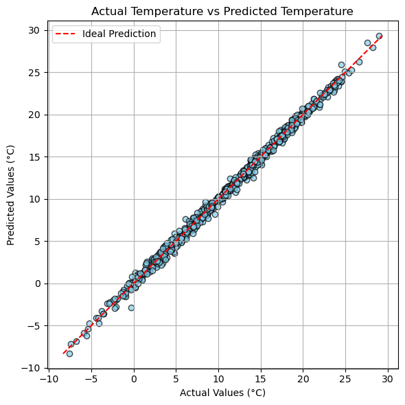

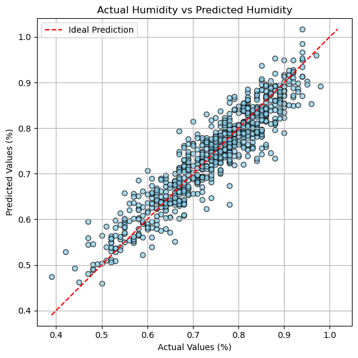

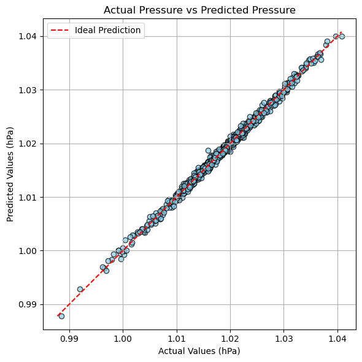

```python
import matplotlib.pyplot as plt

def plot_regression(y_true, y_pred, title, unit):
    plt.figure(figsize=(6, 6)) # Set figure size
    plt.scatter(y_true, y_pred, color='skyblue', edgecolors='k', alpha=0.7)
    max_val = max(max(y_true), max(y_pred))
    min_val = min(min(y_true), min(y_pred))
    plt.plot([min_val, max_val], [min_val, max_val], 'r--', label='Ideal Prediction')

    plt.xlabel(f'Actual Values ({unit})')
    plt.ylabel(f'Predicted Values ({unit})')
    plt.title(title)
    plt.legend()
    plt.grid(True)
    plt.axis('equal')
    plt.tight_layout()
    plt.show()

# Temperature Plot (°C)
plot_regression(y1_test, y1_pred, 'Actual Temperature vs Predicted Temperature', '°C')

# Humidity Plot (%)
plot_regression(y2_test, y2_pred, 'Actual Humidity vs Predicted Humidity', '%')

# Pressure Plot (hPa)
plot_regression(y3_test, y3_pred, 'Actual Pressure vs Predicted Pressure', 'hPa')
```